# Using adehabitatHR, adehabitatLT and sp packages to measure animal home range

## Part 4 - Compare the size of home ranges calculated by MCP and KDE

Start by combining all the data into a single data frame

```r
HRS<-data.frame(MCP_areas$id, MCP_areas$area, KDE_areas$area)
```

Now fix the column names to avoid confusion

```r
colnames(HRS)<-c("Name", "MCP", "KDE")
HRS
```

| Name | MCP | KDE |
| --- | --- | --- |
| Cilla | 324.1863 | 306.2095 |
| Gabs | 210.3761 | 204.8871 |
| Mvubu | 294.0577 | 246.0056 |
| Pepper | 943.7987 | 608.7146 |
| Queen | 582.1266 | 350.5865 |
| Toni | 369.8555 | 261.2040 |

Now we need to re-arrange the data set so that there is a column called “Name”, a column called “Type”, and a column called “Area”. To do so, we’ll use the package called **tidyr**

```r
library(tidyr)
HRS_long<-tidyr::gather(HRS, Type, Area, MCP:KDE, factor_key =T)
HRS_long
```

| Name | Type | Area |
| --- | --- | --- |
| Cilla | MCP | 324.1863 |
| Gabs | MCP | 210.3761 |
| Mvubu | MCP | 294.0577 |
| Pepper | MCP | 943.7987 |
| Queen | MCP | 582.1266 |
| Toni | MCP | 369.8555 |
| Cilla | KDE | 306.2095 |
| Gabs | KDE | 204.8871 |
| Mvubu | KDE | 246.0056 |
| Pepper | KDE | 608.7146 |

[output cut: 2 more lines]

We did that to make it easer to plot the data. Now let’s make a plot!

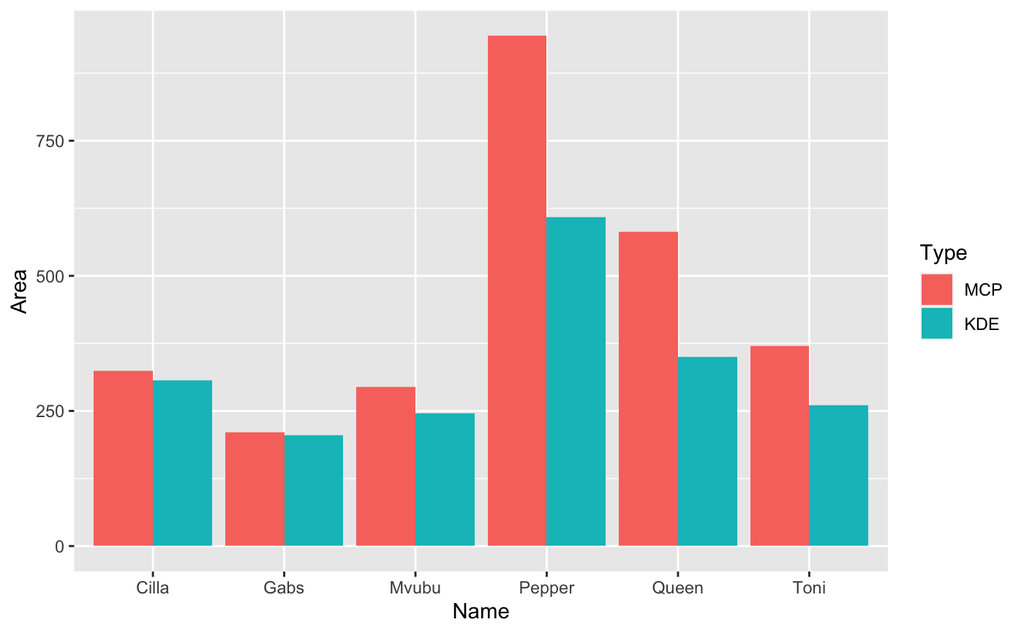

```r
ggplot(HRS_long, aes(Name, Area, fill = Type))+
   geom_col(stat = identity, position = 'dodge')
ggsave("MCPvsKDE.png", device = "png")
```

Can we make any generalizations about MCP vs. KDE estimates based on these results?